# HW4

## Part I

Use the **PopDivas_data.csv** on GitHub to build a prediction model.

1. Explore the Data
   - What patterns/relationships do you notice?
2. Choose/Build Your Model (*Decision Tree* OR *KNN*)
   - Why did you choose this type of model?
   - Which variables are you including in your model?
   - Choose a model validation technique and explain why you chose it.
   - Which variables did you standardize and Why?
3. Evaluate Your Model
   - State how it did (and what evidence/metric do you have to support that?)

## Part II

Use the **YouTubeKidsVideo.csv** on GitHub to build a Naive Bayes Classifier. This dataset looks at the titles/descriptions of YouTube videos that are (1) and are not (0) meant for kids. The variable KidsVideo is 1 if the video is meant for kids, and 0 if it is not. The other variables are 1 if that word (e.g. "toy", "girl"...etc) is in the title/description of the video, and 0 if it is not.

1. Explore the Data
   - What patterns/relationships do you notice?
2. Build your model
   - Which variables are you including in your model?
   - Choose a model validation technique and explain why you chose it.
3. Evaluate Your Model
   - How did it do? What evidence/metric do you have to support that?

# Part I

```python
import warnings
warnings.filterwarnings('ignore')

import pandas as pd
import numpy as np
from plotnine import *
import seaborn as sns
import matplotlib.pyplot as plt
from sklearn.neighbors import KNeighborsClassifier, KNeighborsRegressor
from sklearn.model_selection import train_test_split
from sklearn.naive_bayes import GaussianNB

from sklearn import metrics
from sklearn.preprocessing import StandardScaler, LabelBinarizer
from sklearn.model_selection import KFold # k-fold cv
from sklearn.model_selection import cross_val_score # cross validation metrics
from sklearn.model_selection import cross_val_predict # cross validation metrics
from sklearn.metrics import accuracy_score, confusion_matrix, mean_squared_error
#from sklearn.metrics import plot_confusion_matrix

from sklearn.model_selection import GridSearchCV

%precision %.7g
%matplotlib inline
```

```python
divas = pd.read_csv('data/PopDivas_data.csv')
print(divas.head())
print(divas.info())
print(divas.isnull().sum())
print(divas.describe())
```

```
   Unnamed: 0 artist_name  danceability   energy  key  loudness  mode  \
0           1     Beyoncé         0.386  0.28800    1   -18.513     1
1           2     Beyoncé         0.484  0.36300    5    -8.094     0
2           3     Beyoncé         0.537  0.24700    2   -17.750     1
3           4     Beyoncé         0.672  0.69600    4    -6.693     0
4           5     Beyoncé         0.000  0.00515    9   -22.612     0

   speechiness  acousticness  instrumentalness  liveness  valence  \
0       0.0602         0.533           0.01670    0.1410    0.399
1       0.0368         0.645           0.00000    0.1250    0.201
2       0.0793         0.199           0.00001    0.4230    0.170
3       0.1770         0.200           0.02750    0.0736    0.642
4       0.0000         0.524           0.95000    0.1140    0.000

   duration_ms                    track_name
0        43850    balance (mufasa interlude)
1       226479                        BIGGER
2        46566  the stars (mufasa interlude)
3       162353            FIND YOUR WAY BACK
4        13853   uncle scar (scar interlude)
<class 'pandas.core.frame.DataFrame'>
RangeIndex: 1599 entries, 0 to 1598
Data columns (total 14 columns):
Unnamed: 0          1599 non-null int64
artist_name         1599 non-null object
danceability        1599 non-null float64
energy              1599 non-null float64
key                 1599 non-null int64
loudness            1599 non-null float64
mode                1599 non-null int64
speechiness         1599 non-null float64
acousticness        1599 non-null float64
instrumentalness    1599 non-null float64
liveness            1599 non-null float64
valence             1599 non-null float64
duration_ms         1599 non-null int64
track_name          1599 non-null object
dtypes: float64(8), int64(4), object(2)
memory usage: 175.0+ KB
None
```

[output cut: 29 more lines]

```
min       0.000000     0.000000      0.000025          0.000000     0.016200
25%       0.000000     0.040100      0.016200          0.000000     0.097800
50%       1.000000     0.061500      0.082500          0.000002     0.149000
75%       1.000000     0.151000      0.302500          0.000081     0.310000
max       1.000000     0.960000      0.977000          0.955000     0.993000

           valence   duration_ms
count  1599.000000  1.599000e+03
mean      0.480844  2.215496e+05
std       0.233011  6.732088e+04
min       0.000000  8.619000e+03
25%       0.293000  1.997860e+05
50%       0.467000  2.229860e+05
75%       0.664000  2.491995e+05
max       0.971000  1.187253e+06
```

```python
print(divas['artist_name'].unique())
print(divas['key'].unique())
```

```
['Beyoncé' 'Britney Spears' 'Christina Aguilera' 'Lady Gaga' 'Rihanna'
 'Ariana Grande']
[ 1  5  2  4  9  7  6  0  8  3 10 11]
```

```python
divas['artist_name'] = divas['artist_name'].astype('category')

label_binary = LabelBinarizer()
lb_results = label_binary.fit_transform(divas["artist_name"])
column_names = label_binary.classes_
# lb_results.shape
# column_names

lb_df = pd.DataFrame(lb_results, columns = column_names)
#print(lb_df)

divas = divas.join(lb_df, lsuffix='index', rsuffix='index')

print(divas.head(20))
#combined.drop(combined.columns[9], axis=1, inplace=True)
column_names = divas.columns[15:]
```

```
    Unnamed: 0 artist_name  danceability   energy  key  loudness  mode  \
0            1     Beyoncé         0.386  0.28800    1   -18.513     1
1            2     Beyoncé         0.484  0.36300    5    -8.094     0
2            3     Beyoncé         0.537  0.24700    2   -17.750     1
3            4     Beyoncé         0.672  0.69600    4    -6.693     0
4            5     Beyoncé         0.000  0.00515    9   -22.612     0
5            6     Beyoncé         0.932  0.77500    7    -5.345     0
6            7     Beyoncé         0.563  0.47000    6   -13.470     1
7            8     Beyoncé         0.790  0.69300    0    -5.767     1
8            9     Beyoncé         0.489  0.35300    8   -17.619     1
9           10     Beyoncé         0.484  0.45700    8    -9.458     0
10          11     Beyoncé         0.494  0.41100    6   -15.021     0
11          12     Beyoncé         0.608  0.70900    7    -6.175     1
12          13     Beyoncé         0.000  0.55800    0   -17.238     1
13          14     Beyoncé         0.804  0.82300    0    -3.667     0
```

[output cut: 94 more lines]

```python
divas.head()
```

|  | Unnamed: 0 | artist_name | danceability | energy | key | loudness | mode | speechiness | acousticness | instrumentalness | liveness | valence | duration_ms | track_name | Ariana Grande | Beyoncé | Britney Spears | Christina Aguilera | Lady Gaga | Rihanna |
| --- | --- | --- | --- | --- | --- | --- | --- | --- | --- | --- | --- | --- | --- | --- | --- | --- | --- | --- | --- | --- |
| 0 | 1 | Beyoncé | 0.386 | 0.28800 | 1 | -18.513 | 1 | 0.0602 | 0.533 | 0.01670 | 0.1410 | 0.399 | 43850 | balance (mufasa interlude) | 0 | 1 | 0 | 0 | 0 | 0 |
| 1 | 2 | Beyoncé | 0.484 | 0.36300 | 5 | -8.094 | 0 | 0.0368 | 0.645 | 0.00000 | 0.1250 | 0.201 | 226479 | BIGGER | 0 | 1 | 0 | 0 | 0 | 0 |
| 2 | 3 | Beyoncé | 0.537 | 0.24700 | 2 | -17.750 | 1 | 0.0793 | 0.199 | 0.00001 | 0.4230 | 0.170 | 46566 | the stars (mufasa interlude) | 0 | 1 | 0 | 0 | 0 | 0 |
| 3 | 4 | Beyoncé | 0.672 | 0.69600 | 4 | -6.693 | 0 | 0.1770 | 0.200 | 0.02750 | 0.0736 | 0.642 | 162353 | FIND YOUR WAY BACK | 0 | 1 | 0 | 0 | 0 | 0 |
| 4 | 5 | Beyoncé | 0.000 | 0.00515 | 9 | -22.612 | 0 | 0.0000 | 0.524 | 0.95000 | 0.1140 | 0.000 | 13853 | uncle scar (scar interlude) | 0 | 1 | 0 | 0 | 0 | 0 |

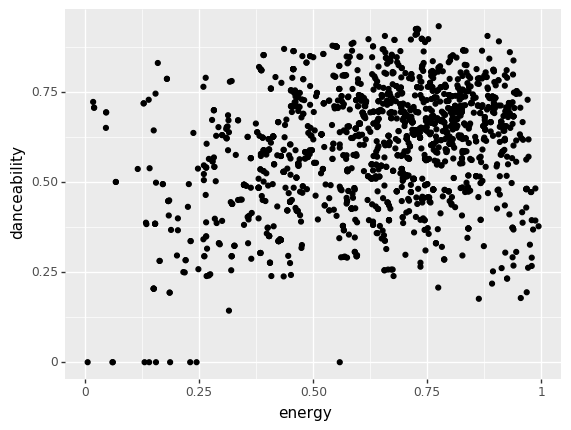

```python
(ggplot(divas, aes(x = "energy", y = "danceability"))
        +geom_point())
```

1a - Seems like there is generally a positive relationship between energy and dancability due to the large cluster in the top right corner

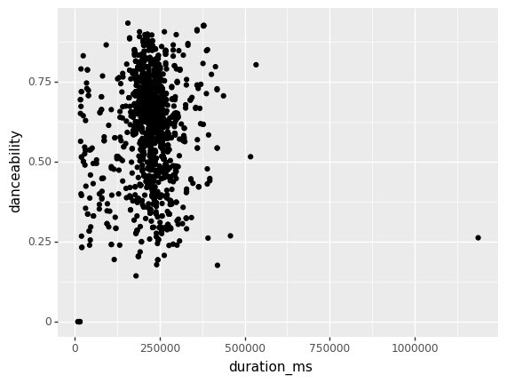

```python
(ggplot(divas, aes(x = "duration_ms", y = "danceability"))
        +geom_point())
```

data is too bunched up to view in this view

```python
divas['duration_s'] = divas['duration_ms'] / 1000

# get rid of interlude songs
divas = divas[divas['duration_s'] > 60]
print(divas.shape)
```

```
(1539, 21)
```

```python
#(divas['duration_s'] > 600).sum()
print(divas.loc[divas['duration_s'] > 600])

# got rid of that mix because it would likely throw off the model
divas = divas[divas['duration_s'] < 600]
```

```
     Unnamed: 0 artist_name  danceability  energy  key  loudness  mode  \
268         269     Beyoncé         0.262   0.971   11    -3.827     0

     speechiness  acousticness  instrumentalness  ...  valence  duration_ms  \
268        0.383         0.108               0.0  ...    0.289      1187253

                                            track_name Ariana Grande  Beyoncé  \
268  Destiny's Child Medley - Audio from The Beyonc...             0        1

     Britney Spears  Christina Aguilera  Lady Gaga  Rihanna  duration_s
268               0                   0          0        0    1187.253

[1 rows x 21 columns]
```

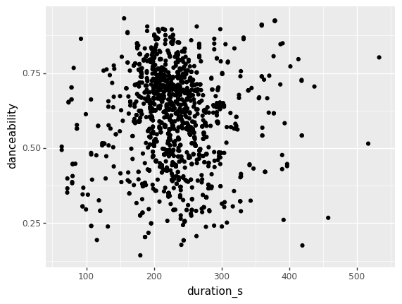

```python
(ggplot(divas, aes(x = "duration_s", y = "danceability"))
        +geom_point())
```

1b - converted to seconds so that its easier to interpret. also removed the destinys child medley so that it wouldnt throw off the model

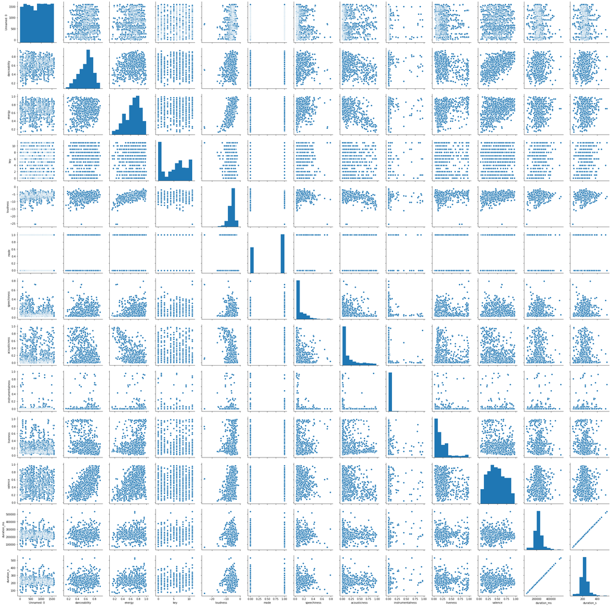

```python
g = sns.pairplot(divas)
```

1c - at a glance valence also looks like it has a positve relationship, as well as loudness a little bit.

```python
predictors = ["valence","duration_s","loudness"]

predictors[2:2] = column_names

#print(predictors)
X = divas[predictors]
y = divas["danceability"]

X_train, X_test, y_train, y_test = train_test_split(X,y, test_size = 0.2)

knn = KNeighborsRegressor()

ks = {"n_neighbors": range(1,30)}

# use grid search to find best parameters
grid = GridSearchCV(knn,ks, scoring = "r2", cv = 5)

zscore = StandardScaler()
zscore.fit(X_train)

Xs_train = zscore.transform(X_train)
Xs_test = zscore.transform(X_test)

knnmod = grid.fit(X_train, y_train)

knnmod.best_estimator_.get_params()["n_neighbors"]
```

```
1
```

```python
poss_k = [1,2,3,4,5,6,7,8,9,10]
acc = {}

for k in poss_k:
    kf = KFold(n_splits = 5)
    knn2 = KNeighborsRegressor(n_neighbors = k)

    acc[k] = np.mean(cross_val_score(knn2, X_train, y_train, cv = kf))

print(acc)

chosen_k = max(acc, key=acc.get)
print(chosen_k)

knn_final = KNeighborsRegressor(n_neighbors = chosen_k)
knn_final.fit(X_train,y_train)

knn_final.score(X_test,y_test)
```

```
{1: 0.3247511583538543, 2: 0.30816326432983165, 3: 0.2830303003513635, 4: 0.25626460996674727, 5: 0.23821537517322752, 6: 0.20528739606340496, 7: 0.18350167613503354, 8: 0.15760007469868254, 9: 0.14593655363540706, 10: 0.1396864875637521}
1
```

```
0.535546400750241
```

2 - I chose KNN as the model to use because I believe artists draw a lot of inspiration from other artists and there might be an interesting relationship between these artists since they were kind of around at the same time and I think knn is an interesting model that might be able to capture this relationship.

```python
train_pred = knnmod.predict(X_train)
test_pred = knnmod.predict(X_test)

print('training r2 is:', knnmod.score(X_train, y_train)) #training R2
print('testing r2 is:', knnmod.score(X_test, y_test)) #testing R2

print('\ntrain mse is: ', mean_squared_error(y_train,train_pred))
print('test mse is: ', mean_squared_error(y_test,test_pred))
```

```
training r2 is: 0.9999997641015631
testing r2 is: 0.19972686224014524

train mse is:  5.691056910568755e-09
test mse is:  0.017059165584415583
```

```python
train_pred = knn_final.predict(X_train)
test_pred = knn_final.predict(X_test)

print('training r2 is:', knn_final.score(X_train, y_train)) #training R2
print('testing r2 is:', knn_final.score(X_test, y_test)) #testing R2

print('\ntrain mse is: ', mean_squared_error(y_train,train_pred))
print('test mse is: ', mean_squared_error(y_test,test_pred))
```

```
training r2 is: 0.9999997915786427
testing r2 is: 0.535546400750241

train mse is:  4.878048780487634e-09
test mse is:  0.011231870129870132
```

# Part II

Use the YouTubeKidsVideo.csv on GitHub to build a Naive Bayes Classifier. This dataset looks at the titles/descriptions of YouTube videos that are (1) and are not (0) meant for kids. The variable KidsVideo is 1 if the video is meant for kids, and 0 if it is not. The other variables are 1 if that word (e.g. "toy", "girl"...etc) is in the title/description of the video, and 0 if it is not.

```
Explore the Data
    What patterns/relationships do you notice?
Build your model
    Which variables are you including in your model?
    Choose a model validation technique and explain why you chose it.
Evaluate Your Model
    How did it do? What evidence/metric do you have to support that?
```

```python
vids = pd.read_csv('data/YouTubeKidsVideo.csv')
print(vids.head())
print(vids.info())
print(vids.isnull().sum())
print(vids.describe())
```

```
   kidsVideo  cat  toy  sad  girl  is
0          1    1    0    0     0   0
1          1    1    0    0     0   0
2          1    1    1    0     0   0
3          1    1    1    0     0   0
4          1    0    0    0     0   0
<class 'pandas.core.frame.DataFrame'>
RangeIndex: 2000 entries, 0 to 1999
Data columns (total 6 columns):
kidsVideo    2000 non-null int64
cat          2000 non-null int64
toy          2000 non-null int64
sad          2000 non-null int64
girl         2000 non-null int64
is           2000 non-null int64
dtypes: int64(6)
memory usage: 93.9 KB
None
kidsVideo    0
cat          0
toy          0
sad          0
girl         0
is           0
dtype: int64
         kidsVideo          cat         toy          sad         girl  \
count  2000.000000  2000.000000  2000.00000  2000.000000  2000.000000
mean      0.500000     0.488000     0.30450     0.234000     0.236000
std       0.500125     0.499981     0.46031     0.423478     0.424728
min       0.000000     0.000000     0.00000     0.000000     0.000000
25%       0.000000     0.000000     0.00000     0.000000     0.000000
50%       0.500000     0.000000     0.00000     0.000000     0.000000
75%       1.000000     1.000000     1.00000     0.000000     0.000000
max       1.000000     1.000000     1.00000     1.000000     1.000000

                is
count  2000.000000
mean      0.145000
std       0.352189
min       0.000000
25%       0.000000
50%       0.000000
75%       0.000000
max       1.000000
```

```python
kids = vids[vids['kidsVideo'] == 1]
not_kids = vids[vids['kidsVideo'] == 0]

print(kids.shape)
print(not_kids.shape)
```

```
(1000, 6)
(1000, 6)
```

[figure not shown]

```python
Data = {'total': [kids['cat'].sum(),kids['toy'].sum(),kids['sad'].sum(),kids['girl'].sum(),kids['is'].sum()]}
df = pd.DataFrame(Data,columns=['total'])
my_labels = 'cat','toy','sad', 'girl', 'is'
plt.pie(df,labels=my_labels,autopct='%1.1f%%')
plt.title('Word Prevalance in Title for YouTube Videos MEANT for Kids')
plt.axis('equal')
plt.show()
```

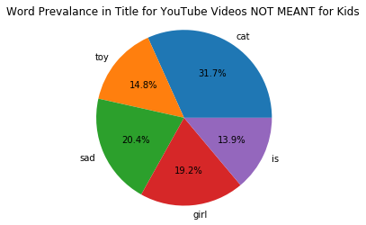

```python
Data = {'total': [not_kids['cat'].sum(),not_kids['toy'].sum(),not_kids['sad'].sum(),not_kids['girl'].sum(),not_kids['is'].sum()]}
df = pd.DataFrame(Data,columns=['total'])
my_labels = 'cat','toy','sad', 'girl', 'is'
plt.pie(df,labels=my_labels,autopct='%1.1f%%')
plt.title('Word Prevalance in Title for YouTube Videos NOT MEANT for Kids')
plt.axis('equal')
plt.show()
```

data shows that there are more titles with the word toy in the title in videos meant for kids. The opposite is true in the case for videos not meant for children, rather sad is a more common word in titles not meant for kids.

```python
predictors = ['toy', 'sad']

X = vids[predictors]
y = vids["kidsVideo"]


kf = KFold(n_splits = 4)
nb = GaussianNB()
acc = []
predictedVals = []
for train, test in kf.split(X,y):
    X_train = X.iloc[train]
    X_test = X.iloc[test]
    y_train = y[train]
    y_test = y[test]



    nb.fit(X_train,y_train)
    acc.append(nb.score(X_test,y_test))
    cnf_matrix = confusion_matrix(y_test, y_test)
    print(cnf_matrix)
```

[output not shown]

```python
print(acc)
print(np.mean(acc))
```

```
[0.46, 0.454, 0.68, 0.666]
0.5650000000000001
```

The model doesnt do too well given a score close to .50 indicating that the model is accurate and useful in half of the time.

```python
get_ipython().system("jupyter nbconvert --output-dir='output/' --to pdf HW4.ipynb")
get_ipython().system("jupyter nbconvert --output-dir='output/' --to markdown HW4.ipynb")
get_ipython().system("jupyter nbconvert --output-dir='output/' --to html HW4.ipynb")
get_ipython().system("jupyter nbconvert --output-dir='output/' --to python HW4.ipynb")
```